# 11-监督学习：回归

### 3 多项式回归

#### 概述：多项式回归的基本概念与数学原理

多项式回归是一种拓展线性回归的监督学习方法，通过添加原始预测因子的高次项来处理响应变量与预测因子之间的非线性关系；特别适用于散点图显示非线性模式的情况——如果是这种情况，多项式回归可以用于探索**不同曲度等级下的预测因子**（自变量）。

1. 通过提升原始预测因子的幂次来获取额外的预测能力，可以处理数据中的曲线关系（非线性关系）。
   - 多项式回归的原理：**将单个预测变量X扩展为多个变量X、X²、X³等，即使用一个预测变量X的多次方（X, X², X³…）作为预测因子。**例如：
     - 一次多项式：就是标准线性回归 (线性关系：直线)：（Y = β₀ + β₁X）
     - 二次多项式：包含X和X²项 (二次曲线：抛物线)：（Y = β₀ + β₁X + β₂X²）
     - 三次多项式：包含X、X²和X³项 (三次曲线：S形曲线)：（Y = β₀ + β₁X + β₂X² + β₃X³）
2. 以分层方式使用，逐步增加模型的复杂度，进而找到最能代表数据集的模型。
3. 对于足够高的（幂）次数，可以生成极端的非线性曲线；但次数通常不超过3-4次，过高可能导致过拟合（在测试集中泛化能力不佳）。
   - 理论上，可以通过提升多项式次数来获得更精确的模型，但过高次数可能导致过拟合，使用超过三次或四次的多项式比较罕见——**因为高次多项式会生成过于灵活的曲线，呈现奇怪形状，可能过度拟合训练数据**。

#### 概述：在R中实现多项式回归

在R中可以通过以下两种方法实现多项式回归：

##### 1. 使用`poly()`函数

###### 1、函数结构

```r
fit_d2 <- lm(nox ~ poly(dis, 2, raw=TRUE), data=Boston)
```

`lm(y ~ poly(x, n, raw=TRUE))` - `x`表示预测因子（名称） - `n`表示多项式的次数 - `raw=TRUE`表示使用原始的非正交多项式

###### 2、工作原理

1. 基本原理
   - 多项式回归的本质是在线性模型中加入非线性项（原始变量的高次幂）。例如，对于一个简单的线性模型：$y = β₀ + β₁x$
   - 我们可以扩展为多项式模型：$y = β₀ + β₁x + β₂x² + β₃x³ + ... + βₙxⁿ$
   - `poly()` 函数的作用就是**帮助我们从原始的x变量生成这些高次项（x², x³等）**，使我们能**在线性模型框架内实现非线性拟合**。
2. `poly()`函数的两种工作模式（通过`raw`参数控制）
- 原始多项式 (raw=TRUE)
  - 第1列: x（一次项）
  - 第2列: x²（二次项）
  - 第3列: x³（三次项）

当设置`raw=TRUE`时，`poly()`直接计算原始变量的幂：

```r
poly(x, 3, raw=TRUE)
```

这种方式直观易懂，但在数值上可能导致共线性问题，特别是当x的值较大或多项式次数较高时。

- 正交多项式 (raw=FALSE，默认)
  - 这时生成的多项式在数学上是正交的，意味着它们之间没有线性相关性。这解决了原始多项式可能带来的数值问题，并提高了计算稳定性。
  - 正交多项式的生成基于一系列复杂的数学变换，本质上是对原始多项式进行线性组合，使得每个生成的多项式都与其他多项式正交。

当默认使用`raw=FALSE`时，`poly()`会生成正交多项式：

```r
poly(x, 3)  # 默认raw=FALSE
```

3. 多项式回归的实现机制

当我们运行以下代码时：

```r
model <- lm(y ~ poly(x, 3, raw=TRUE), data=df)
```

`poly()`函数通过生成原始变量的高次项矩阵，使我们能够使用线性回归的框架处理非线性关系。这种方法的优势在于可以**保持线性模型的简单性和可解释性，同时捕捉数据中的非线性模式**。

##### 2. 使用`I()`包装函数

###### 1、函数结构

```r
fit_d2 <- lm(nox ~ dis + I(dis^2), data=Boston)
```

`lm(y ~ x + I(x^2) + I(x^3))`

- `I()`函数是必要的，因为公式中使用的插入符号`^`没有常规的数学意义（即自乘）
- `I()`函数用于确保插入符号`^`被正确解释为幂运算

###### 2、工作原理

1. 核心功能

`I()` 函数在R语言中是一个”恒等”或”按原样处理”函数，主要用于保护公式中的表达式不被公式语法特殊解析。

2. 工作机制
- 公式语法中，符号如 `+`, `-`, `*`, `^`, `:` 具有特殊含义
- `I()` 函数将括号内的表达式标记为”要按照普通数学表达式处理”
- 当表达式被计算后，结果被视为公式中的单一项
3. 实际应用
   - **多项式项**: `I(x^2)` 表示”x的平方”而非公式语法中的交互项
   - **算术运算**: `I(x+y)` 表示”x加y”而非”包含x和y两个变量”
   - **函数转换**: `I(log(x))` 应用对数转换
   - **逻辑运算**: `I(x > 10)` 创建二值预测变量
4. 在多项式回归中

```r
lm(y ~ x + I(x^2) + I(x^3), data=df)
```

这里，`I()`确保`x^2`和`x^3`被解释为x的平方和立方，而不是公式语法中的其他含义。

5. 本质作用

`I()` 函数在公式语义和数学计算语义之间架起了一座桥梁，使我们能够在R的统计模型公式中嵌入复杂的数学表达式，从而构建更灵活的模型。

#### (1)模型训练：多项式回归——以Boston数据集为例

我们使用Boston数据集作为案例：

先检查的散点图，图中包含了两个变量：nox（因变量）和dis（自变量），在两个变量组成的散点图中、其关系不是线性的——当dis值介于6和12之间时，对应的nox值相对平缓；然而，当dis值小于6时，nox呈现出非线性变化。这些特征说明数据是曲线型的。

```r
library(MASS)
data(Boston)
names(Boston)
```

接下来基于Boston数据集，我们分别使用dis的一次、二次、三次多项式来预测nox，以挖掘多项式回归逐步提升的潜力。以Boston数据集中nox(氮氧化物浓度)和dis(到就业中心的加权距离)之间的关系为例：

##### 1. 一次多项式(线性)拟合

先用lm()函数来拟合一个线性模型——一次多项式就是一元线性回归，回归曲线图是一条直线。

```r
# lm()函数用于拟合线性模型
fit_d1 <- lm(nox~dis, data=Boston)

# 查看拟合出的模型所有组件名称
names(fit_d1)
```

```
##  [1] "coefficients"  "residuals"     "effects"       "rank"
##  [5] "fitted.values" "assign"        "qr"            "df.residual"
##  [9] "xlevels"       "call"          "terms"         "model"
```

```r
# 查看模型的统计摘要以评估拟合质量
  # 一次多项式（一元线性）回归后的R²: 0.5909
summary(fit_d1)
```

```
##
## Call:
## lm(formula = nox ~ dis, data = Boston)
##
## Residuals:
##      Min       1Q   Median       3Q      Max
## -0.12239 -0.05212 -0.01257  0.04391  0.23041
##
## Coefficients:
##              Estimate Std. Error t value Pr(>|t|)
## (Intercept)  0.715343   0.006796  105.26   <2e-16 ***
## dis         -0.042331   0.001566  -27.03   <2e-16 ***
## ---
## Signif. codes:  0 '***' 0.001 '**' 0.01 '*' 0.05 '.' 0.1 ' ' 1
##
## Residual standard error: 0.07412 on 504 degrees of freedom
## Multiple R-squared:  0.5917, Adjusted R-squared:  0.5909
## F-statistic: 730.4 on 1 and 504 DF,  p-value: < 2.2e-16
```

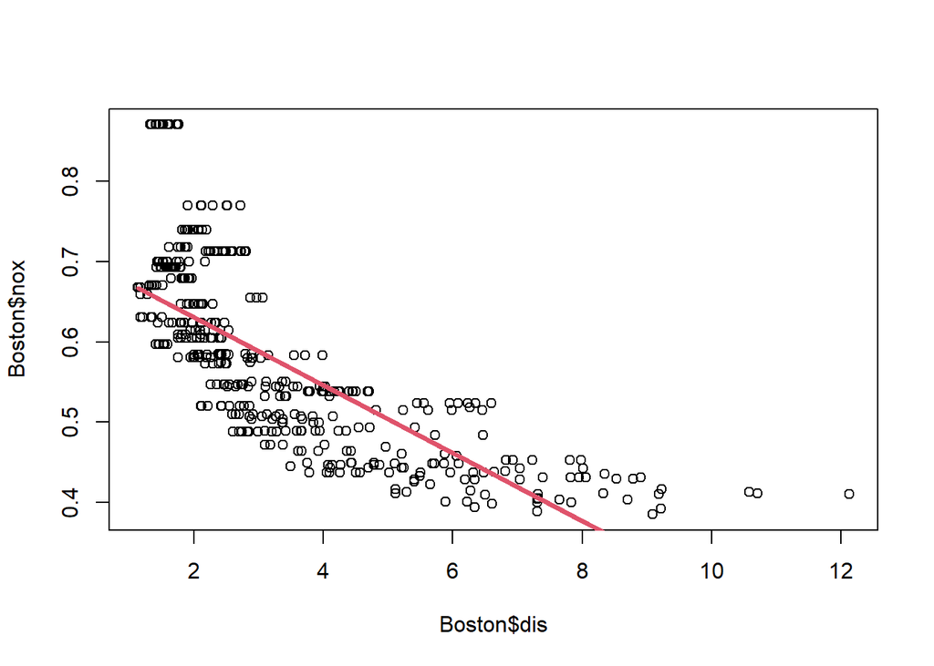

```r
# 绘制真实的dis-nox散点图和基于dis预测因子拟合出的线性回归线，以直观地评估模型是否适合这些数据
plot(Boston$dis, Boston$nox)
  # 创建一个散点图，x轴是dis(距离)，y轴是nox(氮氧化物浓度)
  # 这个图可以直观地展示两个变量之间的关系
  # 这一步骤有助于识别潜在的非线性关系
lines(Boston$dis, fit_d1$fitted, col=2, lwd=3)
```

```r
  # 在散点图上添加回归线：
    # 第一个参数 Boston$dis 是x轴的值
    # 第二个参数fit_d1$fitted是y轴的值（模型预测的nox值）:其中，fit_d1$fitted中的fitted是线性回归模型对象中的一个组件，它代表模型拟合后得到的预测值y值（也称为拟合值）
  # col=2设置线的颜色为红色（在R中，2代表红色）
  # lwd=3设置线的宽度为3（比默认宽度粗）
  # 这条线可以直观地展示线性回归模型是如何拟合数据的
```

如上图，nox和dis之间存在显著的关系，但是这个关系看起来显然是非线性的，数据本身（散点）显示出曲线关系。

###### 重要补充：拟合的线性回归模型对象中的组件

线性回归模型对象（在R中通过`lm()`函数创建）包含许多有用的组件。以下是查询和使用这些组件的方法：

1. 查看模型对象的所有组件

```r
# 创建模型
model <- lm(nox~dis, data=Boston)

# 查看所有组件名称
names(model)
```

```
##  [1] "coefficients"  "residuals"     "effects"       "rank"
##  [5] "fitted.values" "assign"        "qr"            "df.residual"
##  [9] "xlevels"       "call"          "terms"         "model"
```

2. 常用组件及其用途
1. **估计系数**

```r
model$coefficients  # 或简写为 coef(model)
```

```
## (Intercept)         dis
##   0.7153426  -0.0423309
```

返回模型的截距和斜率（回归系数）

2. **拟合值**

```r
model$fitted.values  # 或简写为 model$fitted 或 fitted(model)
```

[output not shown]

[output cut: 73 more lines]

[output not shown]

返回模型预测的y值

3. **残差**

```r
model$residuals  # 或 resid(model)
```

[output not shown]

[output cut: 149 more lines]

[output not shown]

实际y值减去预测y值的差

4. **标准化残差**

```r
rstandard(model)
```

[output not shown]

[output cut: 115 more lines]

[output not shown]

标准化后的残差，用于诊断

5. **杠杆值**

```r
model$hat  # 或 hatvalues(model)
```

[output not shown]

衡量观测值对模型的影响程度

6. **Cook’s距离（基于残差+杠杆值的综合评估）**

```r
cooks.distance(model)
```

[output not shown]

[output cut: 115 more lines]

[output not shown]

衡量单个观测值的影响力

7. **模型矩阵**

```r
model$model  # 或 model.matrix(model)
```

```
##        nox     dis
## 1   0.5380  4.0900
## 2   0.4690  4.9671
## 3   0.4690  4.9671
## 4   0.4580  6.0622
## 5   0.4580  6.0622
## 6   0.4580  6.0622
## 7   0.5240  5.5605
## 8   0.5240  5.9505
## 9   0.5240  6.0821
## 10  0.5240  6.5921
## 11  0.5240  6.3467
## 12  0.5240  6.2267
## 13  0.5240  5.4509
## 14  0.5380  4.7075
```

[output cut: 492 more lines]

用于拟合模型的数据

8. **调用**

```r
model$call
```

```
## lm(formula = nox ~ dis, data = Boston)
```

创建模型时使用的函数调用

9. **自由度**

```r
model$df.residual#残差自由度
```

```
## [1] 504
```

10. **方差-协方差矩阵**

```r
vcov(model)
```

```
##               (Intercept)           dis
## (Intercept)  4.618812e-05 -9.310049e-06
## dis         -9.310049e-06  2.453213e-06
```

系数的方差-协方差矩阵

3. 获取模型信息的函数
1. **模型摘要**

```r
summary(model)
```

```
##
## Call:
## lm(formula = nox ~ dis, data = Boston)
##
## Residuals:
##      Min       1Q   Median       3Q      Max
## -0.12239 -0.05212 -0.01257  0.04391  0.23041
##
## Coefficients:
##              Estimate Std. Error t value Pr(>|t|)
## (Intercept)  0.715343   0.006796  105.26   <2e-16 ***
## dis         -0.042331   0.001566  -27.03   <2e-16 ***
## ---
## Signif. codes:  0 '***' 0.001 '**' 0.01 '*' 0.05 '.' 0.1 ' ' 1
##
## Residual standard error: 0.07412 on 504 degrees of freedom
## Multiple R-squared:  0.5917, Adjusted R-squared:  0.5909
## F-statistic: 730.4 on 1 and 504 DF,  p-value: < 2.2e-16
```

提供全面的统计摘要，包括R²、F统计量等

2. **方差分析表**

```r
anova(model)
```

```
## Analysis of Variance Table
##
## Response: nox
##            Df Sum Sq Mean Sq F value    Pr(>F)
## dis         1 4.0124  4.0124  730.43 < 2.2e-16 ***
## Residuals 504 2.7686  0.0055
## ---
## Signif. codes:  0 '***' 0.001 '**' 0.01 '*' 0.05 '.' 0.1 ' ' 1
```

提供方差分析结果

3. **估计系数的置信区间**

```r
confint(model)
```

```
##                   2.5 %      97.5 %
## (Intercept)  0.70199028  0.72869496
## dis         -0.04540813 -0.03925367
```

计算系数的置信区间

4. **预测函数**

```r
predict(model, newdata=data.frame(dis=c(4, 5, 6)))
```

```
##         1         2         3
## 0.5460190 0.5036881 0.4613572
```

用模型预测新的数据点

5. **影响力测量**

```r
influence.measures(model)
```

```
## Influence measures of
##   lm(formula = nox ~ dis, data = Boston) :
##
##        dfb.1_   dfb.dis     dffit cov.r   cook.d     hat inf
## 1   -9.15e-04 -3.54e-04 -0.002552 1.006 3.26e-06 0.00202
## 2    5.41e-05 -1.21e-02 -0.024819 1.006 3.08e-04 0.00259
## 3    5.41e-05 -1.21e-02 -0.024819 1.006 3.08e-04 0.00259
## 4    2.00e-04 -4.70e-04 -0.000641 1.008 2.06e-07 0.00427
## 5    2.00e-04 -4.70e-04 -0.000641 1.008 2.06e-07 0.00427
## 6    2.00e-04 -4.70e-04 -0.000641 1.008 2.06e-07 0.00427
## 7   -6.60e-03  2.22e-02  0.034579 1.006 5.99e-04 0.00337
## 8   -1.50e-02  3.74e-02  0.052191 1.005 1.36e-03 0.00405
## 9   -1.86e-02  4.33e-02  0.058823 1.005 1.73e-03 0.00431
## 10  -3.59e-02  7.04e-02  0.088040 1.004 3.87e-03 0.00547
## 11  -2.69e-02  5.65e-02  0.073271 1.005 2.68e-03 0.00488
```

[output cut: 495 more lines]

计算多种影响力统计量

4. 实际例子

```r
# 创建模型
fit <- lm(nox~dis, data=Boston)

# 基本组件
coef(fit)           # 查看系数
```

```
## (Intercept)         dis
##   0.7153426  -0.0423309
```

```r
fitted(fit)         # 查看拟合值
```

[output not shown]

[output cut: 73 more lines]

[output not shown]

```r
resid(fit)          # 查看残差
```

[output not shown]

[output cut: 149 more lines]

[output not shown]

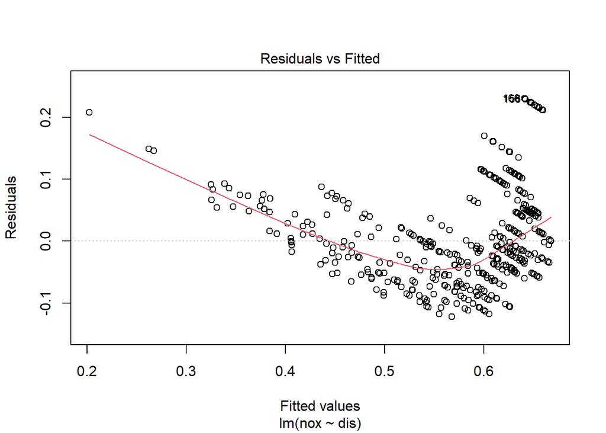

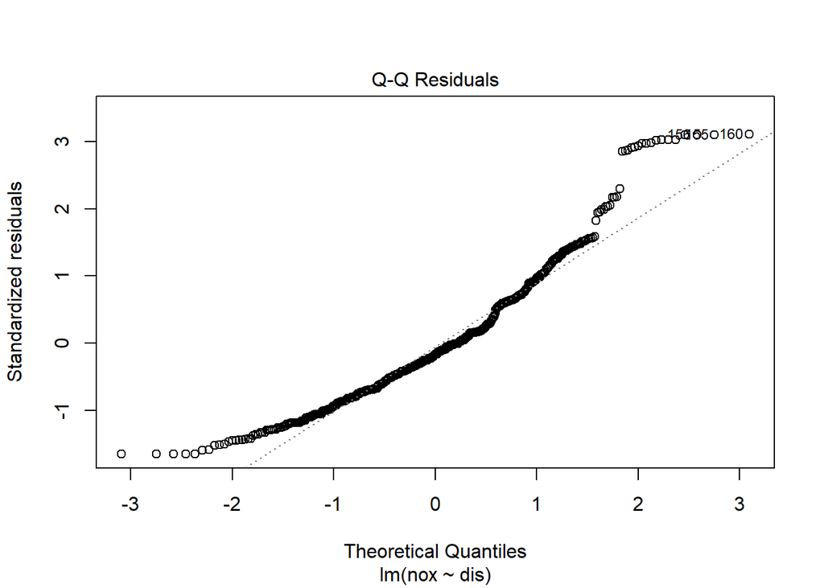

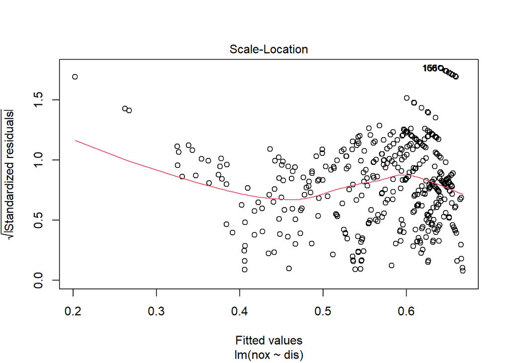

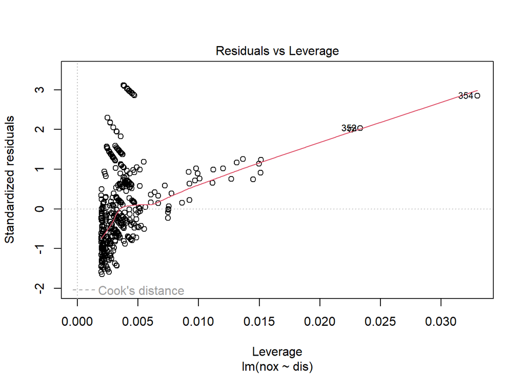

```r
# 模型诊断
plot(fit)           # 生成模型诊断图
```

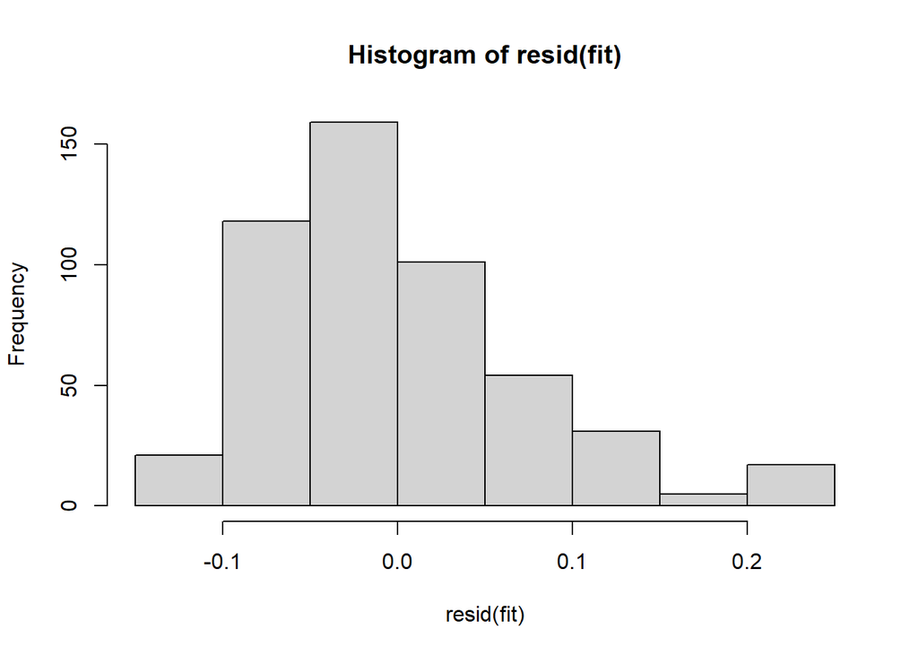

```r
hist(resid(fit))    # 残差直方图
```

```r
# 预测
new_data <- data.frame(dis=c(2, 4, 6))
predict(fit, newdata=new_data)
```

```
##         1         2         3
## 0.6306808 0.5460190 0.4613572
```

这些组件和函数让你可以全面分析和利用回归模型的结果，进行模型诊断和预测。

##### 2. 二次多项式拟合

对于更高次数的回归方程式，我们将使用`poly()`函数来提升`dis`的幂次数——使用`poly(dis,2,raw=TRUE)`生成了一个506行×2列的矩阵，用于二次多项式回归。这个矩阵的结构如下：

1. **行数**: 506行，对应Boston数据集中的506个观测值。
2. **列数**: 2列，分别对应：
- 第一列: dis（一次项）
- 第二列: dis²（二次项）

当用于回归时，这个矩阵被用作预测变量，允许模型同时考虑线性项和二次项。参数`raw=TRUE`表示使用原始的非正交多项式。

另一种创造多项式基函数的方法是上面提到的R中的`I()`包装函数。不论哪种情况，我们都创造了一个非线性拟合；熟悉的非线性二次型曲线如下图所示：

```r
# 拟合二次模型
fit_d2 <- lm(nox ~ poly(dis, 2, raw=TRUE), data=Boston)

# 调整后的R²: 0.6987
summary(fit_d2)
```

```
##
## Call:
## lm(formula = nox ~ poly(dis, 2, raw = TRUE), data = Boston)
##
## Residuals:
##       Min        1Q    Median        3Q       Max
## -0.129559 -0.044514 -0.007753  0.025778  0.201882
##
## Coefficients:
##                            Estimate Std. Error t value Pr(>|t|)
## (Intercept)                0.843991   0.011196   75.39   <2e-16 ***
## poly(dis, 2, raw = TRUE)1 -0.111628   0.005320  -20.98   <2e-16 ***
## poly(dis, 2, raw = TRUE)2  0.007135   0.000530   13.46   <2e-16 ***
## ---
## Signif. codes:  0 '***' 0.001 '**' 0.01 '*' 0.05 '.' 0.1 ' ' 1
##
## Residual standard error: 0.06361 on 503 degrees of freedom
## Multiple R-squared:  0.6999, Adjusted R-squared:  0.6987
## F-statistic: 586.4 on 2 and 503 DF,  p-value: < 2.2e-16
```

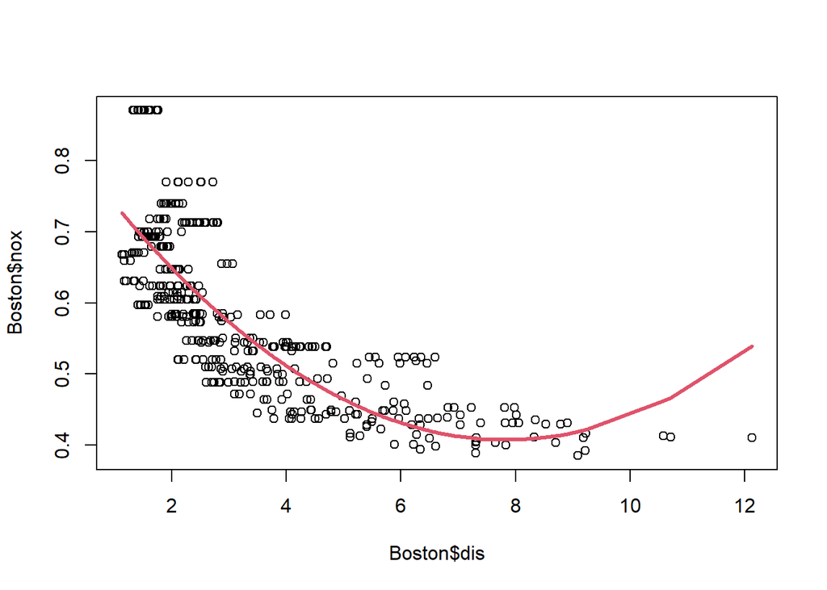

```r
# 绘制原始数据的散点图，查看其分布模式
plot(Boston$dis, Boston$nox)

# 为什么这里要排序？
# 在代码‘lines(sort(Boston$dis), fit_d2$fitted.values[order(Boston$dis)], col=2, lwd=3)’中，我们看到对 Boston$dis 进行了排序，同时也按照相同的顺序重排了拟合值。
# 为什么？
  # 1、lines()函数的连接方式:lines()函数按照点在数据中出现的顺序依次连接。它不会自动将点按x值从小到大排序后再连线。

  # 2、无序数据的问题：如果原始数据（Boston$dis）不是按照从小到大排序的，那么绘制的线条会根据数据在数据框中的原始顺序连接点，而不是按照 x 轴从左到右的顺序。

  # 3、交叉线而非平滑曲线：对于非线性关系（如二次曲线），如果点不按x值排序，线条会来回交叉，看起来像一个杂乱的折线图，而不是我们期望的平滑曲线。
lines(sort(Boston$dis),
      fit_d2$fitted.values[order(Boston$dis)],
      col = 2,
      lwd = 3)
```

注意：二次项拟合比只有线性项的拟合效果好一点。同时也要注意，二次拟合的R<sup>2</sup>值为0.6999，作为对比，线性拟合的R<sup>2</sup>值为0.5917，提升并不是很大。

##### 3. 三次多项式拟合

现在用三次多项式拟合线性模型。

如上面所说，一图胜千言，基于数据的多项式拟合生成的非线性曲线图表，是评估拟合质量的一种强大方式；如下图展示，三次项回归展现出了优良的拟合。

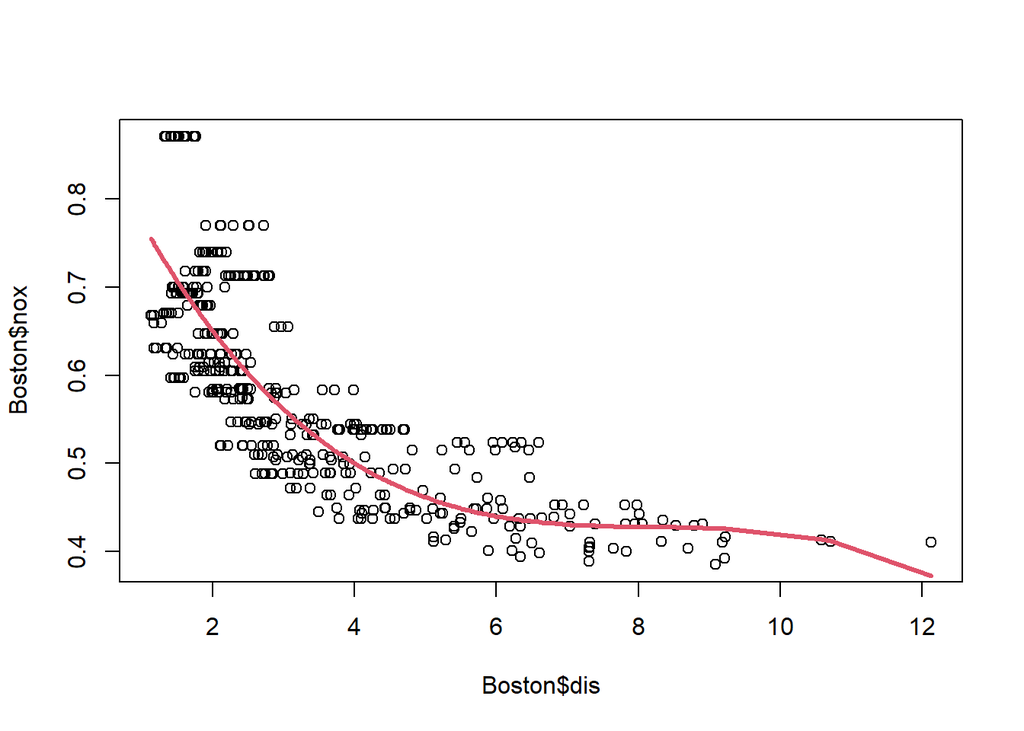

```r
# 拟合三次模型
fit_d3 <- lm(nox ~ poly(dis, 3, raw=TRUE), data=Boston)

plot(Boston$dis, Boston$nox)

lines(sort(Boston$dis),
      fit_d3$fitted.values[order(Boston$dis)],
      col = 2,
      lwd = 3)
```

但仅仅是图是不够的，我们还需要看`lm()`返回的每一个多项式次数对应的统计量：

```r
# 调整后的R²: 0.7131
summary(fit_d3)
```

```
##
## Call:
## lm(formula = nox ~ poly(dis, 3, raw = TRUE), data = Boston)
##
## Residuals:
##       Min        1Q    Median        3Q       Max
## -0.121130 -0.040619 -0.009738  0.023385  0.194904
##
## Coefficients:
##                             Estimate Std. Error t value Pr(>|t|)
## (Intercept)                0.9341281  0.0207076  45.110  < 2e-16 ***
## poly(dis, 3, raw = TRUE)1 -0.1820817  0.0146973 -12.389  < 2e-16 ***
## poly(dis, 3, raw = TRUE)2  0.0219277  0.0029329   7.476 3.43e-13 ***
## poly(dis, 3, raw = TRUE)3 -0.0008850  0.0001727  -5.124 4.27e-07 ***
## ---
## Signif. codes:  0 '***' 0.001 '**' 0.01 '*' 0.05 '.' 0.1 ' ' 1
##
## Residual standard error: 0.06207 on 502 degrees of freedom
## Multiple R-squared:  0.7148, Adjusted R-squared:  0.7131
## F-statistic: 419.3 on 3 and 502 DF,  p-value: < 2.2e-16
```

```r
# 返回三次多项式回归模型的系数表；这个命令做了两件事：
  # summary(fit_d3) 生成模型的详细摘要信息
  # coef() 从摘要中提取系数表

# 返回的结果是一个矩阵，包含以下几列：
  # Estimate: 每个系数的估计值
  # Std. Error: 每个系数估计的标准误差
  # t value: t统计量（系数估计除以其标准误差）
  # Pr(>|t|): p值，表示系数显著性
coef(summary(fit_d3))
```

```
##                                Estimate   Std. Error    t value      Pr(>|t|)
## (Intercept)                0.9341280720 0.0207076150  45.110365 9.853624e-179
## poly(dis, 3, raw = TRUE)1 -0.1820816950 0.0146973264 -12.388763  6.078843e-31
## poly(dis, 3, raw = TRUE)2  0.0219276580 0.0029329119   7.476412  3.428917e-13
## poly(dis, 3, raw = TRUE)3 -0.0008849957 0.0001727172  -5.123959  4.274950e-07
```

有一些关键的指标如下：

- **拟合的决定系数（也被称为R<sup>2</sup>）**：表明可以用模型解释的数据集中异常值（变异）的百分比。R<sup>2</sup> 越接近1，拟合模型越能完整地“解释”数据（的变异）。注意到，随着多项式次数的提高，调整后的决定系数也提高：0.5909、0.6987和0.7131。
- **拟合的F-统计量（F-statistic）**：比较模型解释的数据变异分数和模型无法解释的数据变异分数的“大小”——即模型变异（可解释变异）和误差（残差：不可解释变异）的比值。F-统计量的值“大”，通常> 6，表示拟合是有意义的。
- **回归系数的t-统计量（也称为“t值”）**：表示每一个回归系数的显著性水平——t-统计量定义为回归系数和其标准误差的比值；如果一个回归系数的t值为2或者更高，那么这个回归系数通常是显著的。

#### (2)模型评估与选择

如何确定最适合的多项式次数？主要通过以下方法：

##### 1. 统计指标（R2、F统计量和t统计量的对比）

1. **拟合的决定系数（也被称为R<sup>2</sup>）**：**确定的某一模型（不是用来比较不同模型的指标，是比较当前模型的指标）**，R2表明可以用模型解释的数据集中异常值（变异）的百分比。R<sup>2</sup> 越接近1，拟合模型越能完整地“解释”数据（的变异）。注意到，随着多项式次数的提高，调整后的决定系数也提高：0.5909、0.6987和0.7131。
2. **拟合的F-统计量（F-statistic）**：**不同模型间**，比较**模型整体**解释的数据变异分数和**模型整体**无法解释的数据变异分数的“大小”——即模型变异（可解释变异）和误差（残差：不可解释变异）的比值。F-统计量的值“大”，通常> 6，表示拟合是有意义的。如果模型调整后F统计值变大，说明模型整体性能进步了。
3. **回归系数的t-统计量（也称为“t值”）**：**不同模型间**，表示**模型中每一个回归系数的显著性水平**——t-统计量定义为回归系数和其标准误差的比值。如果一个回归系数的t值为2或者更高，那么这个回归系数通常是显著的，回归系数显著不为 0 表示自变量（预测变量）与因变量之间存在统计上显著的关系，这不是偶然的，而是数据中确实存在的模式。

   **在多项式回归的特定情况下，如果高次项（如二次项、三次项）的系数显著不为0，则表明数据中存在非线性关系，简单的线性模型不足以准确描述变量之间的关系——这支持了使用更复杂模型（包含高次项）的决定。**

   **例如，在三次多项式模型中，三次项系数显著不为0表明使用三次曲线比二次曲线更适合描述数据中的关系，证实了模型选择的合理性。**
   - 注意：有人可能因为残差和标准化残差（残差除以残差标准误差）的关系，就认为回归系数和t-统计量（回归系数除以回归系数标准误差）的关系也是类似的；实际上回归系数和标准化回归系数（`回归系数 × (自变量标准差 / 因变量标准差)`）的关系才类似于残差与标准化残差的关系。具体区分如下：
   1. t统计量与标准化回归系数是两个不同的概念，虽然它们都可以用来评估变量的重要性。
      - t统计量的计算公式是：`t = 回归系数 / 回归系数的标准误差`
        - 它主要用于检验回归系数是否显著不等于零，衡量的是系数估计值相对于其抽样变异性的大小。t值越大（绝对值意义上），表示该系数越显著不同于零，说明其和因变量的关系就越显著。
      - 而标准化回归系数（也称Beta系数）的计算公式是：`Beta = 回归系数 × (自变量标准差 / 因变量标准差)`
        - 标准化系数表示自变量变动一个标准差时，因变量预期变动的标准差数量，使不同量纲的变量效应可比较。
   2. 主要区别
      - t统计量：评估系数的统计显著性
      - 标准化系数：对偏回归系数进行标准化，评估不同变量影响的相对大小，允许比较不同单位的变量到底谁对预测因变量的影响更大

##### 2. 方差分析(ANOVA)（基于F统计量比较不同模型）

###### 1、为什么需要确定多项式的次数

1. **模型复杂度与拟合能力**  
   在多项式回归中，增加多项式的阶数（也就是在模型中加入更高次项）通常会带来更高的拟合能力。因为额外的项可以让模型捕捉更复杂、更细微的非线性关系。
2. **过度拟合（Overfitting）的风险**  
   虽然更高阶的多项式能更好地“贴近”训练数据，但也更可能出现过度拟合。过度拟合是指模型在训练样本上表现优异，但对新数据的预测性能（泛化能力）较差。换句话说，模型“记住”了数据的噪声和细枝末节，反而失去了对真实关系的把握。
3. **平衡与取舍**  
   因此，我们需要在模型的复杂度（多项式阶数）与模型的可解释性、泛化能力之间进行平衡。选择一个过于简单的模型（如只有线性项）可能欠拟合，难以捕捉数据的真实结构；选择一个过于复杂的模型（如高阶多项式）又可能过度拟合，无法泛化。

###### 2、如何使用方差分析（ANOVA）比较模型

   如果某一行（对应某个模型与前一个模型的对比）的 Pr(>F) 值很小（通常小于 0.05），我们就拒绝零假设，意味着“新模型的加入项确实能显著提高模型对数据的解释能力”。

###### 3、本案例：从线性到二次、再到三次多项式的比较

结合以上思路，我们现在依次比较本例中的三个模型，得到如下结论：

1. **Model 1（一次多项式）与 Model 2（二次多项式）的比较**
   - 如果 **Model 2（二次多项式）**Pr(>F) 很小（比如 2.2e-16 远小于 0.05），则说明相较于线性模型（一次多项式），二次多项式显著改善了对数据的拟合效果。
2. **Model 2（二次多项式）与 Model 3（三次多项式）的比较**
   - 接着比较二次多项式与三次多项式。如果**Model 3（三次多项式）**Pr(>F) 依然很小，则表示三次多项式在捕捉数据的非线性关系方面做得更好，具有更高的解释力。
3. **是否继续增加更高阶**
   - 你可能会问：“为什么不继续用四次、五次甚至更高的多项式？”
   - 原因在于：随着阶数的增加，过度拟合的风险越来越大，并且从实践角度看，每增加一阶就需要更多的数据量以支撑模型的稳健性，且解释变得更加困难。通常，三次或四次多项式就已经能很好地捕捉常见的非线性结构，再往上继续增加阶数收效不一定显著，还会失去简洁性和可解释性。

###### 4、核心总结

1. **模型的阶数决定了模型（拟合）的灵活度**。
2. **使用 ANOVA** 等方法可以客观地比较不同阶的多项式模型，从而确定更合理的模型复杂度。
3. **在实践中要警惕过度拟合：**有些时候，通过交叉验证或其他模型评估指标也可判断模型的泛化性能，以此来辅助选择最优的多项式阶数。
4. **可解释性**也非常重要：从可视化或统计显著性的角度看，当模型复杂度提高，解释难度也会增加，要在模型质量和可解释性之间做好折中。

##### 3. 可视化评估

通过绘制不同次数多项式的拟合曲线，直观评估拟合质量。对Boston数据集而言，三次多项式提供了最佳的拟合曲线。

#### (3)多项式回归的应用注意事项

- 多项式回归适用于探索预测因子的不同曲度等级
- 过高次数的多项式可能导致过拟合
- 需要平衡**模型复杂度/变量数量（正则化）**与**拟合效果（参数估计）：正则化配合参数估计，寻找解释模型变异的最优复杂度+最优参数——即最好的参数配上最适合的变量数量**
- 应结合统计检验和可视化评估选择最佳多项式次数

通过多项式回归，可以有效建模非线性关系，提高预测精度，但需谨慎选择适当的模型复杂度。

### 4 阶段总结

回归是历史最悠久也是人们理解最深入的算法，它在众多领域都有着广泛的使用。截止目前，我们讨论了3种回归形式：一元线性回归、多元线性回归和多项式回归。但这不是回归的结束。还有其他类型的回归算法，例如岭回归（ridge regression）和拉索（lasso）等收缩（shrinkage）方法，用于降低在回归系数趋近于0的情况下产生的误差。

在回归模型使用的过程中，控制模型的复杂度（变量数量）和优化模型的参数以实现拟合训练的最优解，是**模型训练**的核心内容。为此，通过**正则化方法**控制模型的复杂度/变量数量，通过**参数估计**提升模型参数的拟合效果，须二者配合达成平衡才有抵达这最优解的可能——寻找解释模型变异的最优复杂度+最优参数、即**最好的参数配上最适合的变量数量**。

下面是阶段小结：

- 我们从使用R中的lm()函数提供的最小二乘计算工具开始，探索一元线性回归。
  - 在summary()函数的帮助下，我们评估了一系列模型拟合的评估和诊断措施，例如模型的拟合值、回归系数、残差、标准误差、t值、假设几率（|Pr|>t）和F-统计量
  - 我们发现一旦训练了模型，就可以用新数据进行预测。
  - 我们探索了一系列评估模型拟合质量的重要图表：残差-拟合值图、Q-Q图、Cook‘s距离图等
- 然后我们学习了如何将一元线性回归算法扩展到使用多元线性回归的多元预测因子：在这里，我们使用了一种机器学习常用的技术，即将数据集拆分成训练集和测试集。
  - 我们也用一元线性回归中的相同方法来评估模型的拟合程度，同时也看了一些新的诊断图：例如残差-索引图（目的有点类似于Cook’s距离图）。
- 为了处理响应变量和预测因子之间的非线性关系，我们的注意力转向了多项式回归，并探索了不同幂次的多项式如何提升拟合的质量。

### 5 多元多项式回归方法

#### 1. 基本概念与数学模型

多元多项式回归是将多元回归和多项式回归结合的统计方法，其数学模型为：

$y = β₀ + β₁x₁ + β₂x₂ + ... + β₁₁x₁² + β₂₂x₂² + ... + β₁₂x₁x₂ + ... + ε$

这种模型包含： - 线性项：β₁x₁, β₂x₂, … - 二次项：β₁₁x₁², β₂₂x₂², … - 交互项：β₁₂x₁x₂, …

此模型通过高次项捕捉非线性关系，通过交互项分析变量间相互作用。

#### 2. 构建与实现步骤

##### 1、特征构建

- 从原始变量生成多项式特征
- 确定多项式阶数（一般从2阶开始尝试）
- 生成交互项特征

##### 2、参数估计

- 通常采用普通最小二乘法(OLS)估计参数
- 可转化为矩阵形式求解：β = (X^T X)^(-1) X^T y

##### 3、模型选择

- 使用逐步回归方法筛选变量
- 应用信息准则（如AIC、BIC）评估模型
- 使用交叉验证选择最佳阶数

#### 3. 编程实现方法

Python实现示例：

```python
# 使用scikit-learn库
from sklearn.preprocessing import PolynomialFeatures
from sklearn.linear_model import LinearRegression
from sklearn.pipeline import Pipeline

# 创建多项式特征转换器和线性回归模型的管道
model = Pipeline([
    ('poly', PolynomialFeatures(degree=2, include_bias=False)),
    ('linear', LinearRegression())
])

# 拟合模型
model.fit(X, y)
```

R语言实现示例：

```r
# 创建多项式回归模型
model <- lm(y ~ poly(x1, 2) + poly(x2, 2) + x1:x2, data=df)
```

#### 4. 模型评估与诊断

##### 1、拟合优度评估

- 决定系数(R²)和调整后的R²
- 均方误差(MSE)和均方根误差(RMSE)
- F统计量检验整体显著性

##### 2、残差分析

- 残差的正态性检验
- 残差图检查同方差性
- 检测异常值和高杠杆点

##### 3、多重共线性诊断

- 计算方差膨胀因子(VIF)
- 使用主成分分析或岭回归应对多重共线性

#### 5. 优势与局限性

##### 优势

- 能够捕捉复杂的非线性关系
- 保持了线性回归的可解释性

##### 局限性

- 特征数量随变量数和阶数指数增长
- 容易出现过拟合问题
- 模型复杂度增加导致解释难度增大
- 对异常值敏感度高

#### 6. 实际应用领域与案例

- 经济与金融
  - 股票价格非线性预测
  - 宏观经济指标关系建模
- 工程与制造
  - 产品质量与多因素关系分析
  - 工艺参数优化
- 生物医学
  - 药物剂量与效应的非线性关系
  - 多基因交互作用分析
- 环境科学
  - 气候因素与污染物浓度关系
  - 生态系统多因素互动模型